# Machine learning Project : EasyVisa

### Context

Business communities in the United States are facing high demand for human resources, but one of the constant challenges is identifying and attracting the right talent, which is perhaps the most important element in remaining competitive. Companies in the United States look for hard-working, talented, and qualified individuals both locally as well as abroad.

The Immigration and Nationality Act (INA) of the US permits foreign workers to come to the United States to work on either a temporary or permanent basis. The act also protects US workers against adverse impacts on their wages or working conditions by ensuring US employers' compliance with statutory requirements when they hire foreign workers to fill workforce shortages. The immigration programs are administered by the Office of Foreign Labor Certification (OFLC).

OFLC processes job certification applications for employers seeking to bring foreign workers into the United States and grants certifications in those cases where employers can demonstrate that there are not sufficient US workers available to perform the work at wages that meet or exceed the wage paid for the occupation in the area of intended employment.

### Objective

In fiscal year 2016, the OFLC reviewed 775,979 employer applications covering 1,699,957 positions for both temporary and permanent labor certifications. This marked a 9% increase compared to the previous year, making the manual review process increasingly time-consuming due to the growing number of applicants.

To manage this rising volume efficiently, there is a need for a machine learning-based solution that can help identify candidates with a higher likelihood of visa approval. To address this, OFLC has partnered with the data analytics firm EasyVisa. As a data scientist at EasyVisa, your role is to analyze the provided dataset and build a classification model to:

1. Streamline and accelerate the visa approval process.
2. Recommend applicant profiles that are more likely to be approved or denied, based on key factors influencing the case outcome.

### Dataset

The data contains the different attributes of the employee and the employer. The detailed data dictionary is given below.

- case_id: ID of each visa application
- continent: Information of continent the employee
- education_of_employee: Information of education of the employee
- has_job_experience: Does the employee has any job experience? Y = Yes; N = No
- requires_job_training: Does the employee require any job training? Y = Yes; N = No
- no_of_employees: Number of employees in the employer’s company
- yr_of_estab: Year in which the employer's company was established
- region_of_employment: Information of foreign worker's intended region of employment in the US.
- prevailing_wage: Average wage paid to similarly employed workers in a specific occupation in the area of intended employment. The purpose of the prevailing wage is to ensure that the foreign worker is not underpaid compared to other workers offering the same or similar service in the same area of employment.
- unit_of_wage: Unit of prevailing wage. Values include Hourly, Weekly, Monthly, and Yearly.
- full_time_position: Is the position of work full-time? Y = Full-Time Position; N = Part-Time Position
- case_status: Flag indicating if the Visa was certified or denied

## Importing the necessary libraries

```python
# Libraries to help with reading and manipulating data
import pandas as pd
import numpy as np

# Libaries to help with data visualization
import matplotlib.pyplot as plt
import seaborn as sns

# To tune model, get different metric scores, and split data
from sklearn.metrics import (
    f1_score,
    accuracy_score,
    recall_score,
    precision_score,
    confusion_matrix,
    roc_auc_score,
    ConfusionMatrixDisplay,
)
from sklearn.model_selection import train_test_split, StratifiedKFold, cross_val_score

# To be used for data scaling and one hot encoding
from sklearn.preprocessing import StandardScaler, MinMaxScaler, OneHotEncoder

# To impute missing values
from sklearn.impute import SimpleImputer
from sklearn import metrics

# To oversample and undersample data
from imblearn.over_sampling import SMOTE
from imblearn.under_sampling import RandomUnderSampler

# To do hyperparameter tuning
from sklearn.model_selection import RandomizedSearchCV

# To define maximum number of columns to be displayed in a dataframe
pd.set_option("display.max_columns", None)

# To supress scientific notations for a dataframe
pd.set_option("display.float_format", lambda x: "%.3f" % x)

# To help with model building
from sklearn.tree import DecisionTreeClassifier
from sklearn.ensemble import (
    AdaBoostClassifier,
    GradientBoostingClassifier,
    RandomForestClassifier,
    BaggingClassifier,
)
from xgboost import XGBClassifier
from sklearn.linear_model import LogisticRegression

# To suppress scientific notations
pd.set_option("display.float_format", lambda x: "%.3f" % x)

# To supress warnings
import warnings

warnings.filterwarnings("ignore")
```

## Loading the dataset

```python
# Connect to Google Colab
from google.colab import drive
drive.mount('/content/drive')
```

```python
# Write your code here to read the data
data = pd.read_csv("/content/drive/MyDrive/PythonPrograms/Advanced_Machine_Learning/EasyVisa.csv")
```

```python
# copying data to another varaible to avoid any changes to original data
Visa = data.copy()
```

## Data Overview

### View the first and last 5 rows of the dataset.

```python
# To read first 5 rows of the dataset
Visa.head()
```

|  | case_id | continent | education_of_employee | has_job_experience | requires_job_training | no_of_employees | yr_of_estab | region_of_employment | prevailing_wage | unit_of_wage | full_time_position | case_status |
| --- | --- | --- | --- | --- | --- | --- | --- | --- | --- | --- | --- | --- |
| 0 | EZYV01 | Asia | High School | N | N | 14513 | 2007 | West | 592.203 | Hour | Y | Denied |
| 1 | EZYV02 | Asia | Master's | Y | N | 2412 | 2002 | Northeast | 83425.650 | Year | Y | Certified |
| 2 | EZYV03 | Asia | Bachelor's | N | Y | 44444 | 2008 | West | 122996.860 | Year | Y | Denied |
| 3 | EZYV04 | Asia | Bachelor's | N | N | 98 | 1897 | West | 83434.030 | Year | Y | Denied |
| 4 | EZYV05 | Africa | Master's | Y | N | 1082 | 2005 | South | 149907.390 | Year | Y | Certified |

```python
# To read last 5 entries of the dataset
Visa.tail()
```

|  | case_id | continent | education_of_employee | has_job_experience | requires_job_training | no_of_employees | yr_of_estab | region_of_employment | prevailing_wage | unit_of_wage | full_time_position | case_status |
| --- | --- | --- | --- | --- | --- | --- | --- | --- | --- | --- | --- | --- |
| 25475 | EZYV25476 | Asia | Bachelor's | Y | Y | 2601 | 2008 | South | 77092.570 | Year | Y | Certified |
| 25476 | EZYV25477 | Asia | High School | Y | N | 3274 | 2006 | Northeast | 279174.790 | Year | Y | Certified |
| 25477 | EZYV25478 | Asia | Master's | Y | N | 1121 | 1910 | South | 146298.850 | Year | N | Certified |
| 25478 | EZYV25479 | Asia | Master's | Y | Y | 1918 | 1887 | West | 86154.770 | Year | Y | Certified |
| 25479 | EZYV25480 | Asia | Bachelor's | Y | N | 3195 | 1960 | Midwest | 70876.910 | Year | Y | Certified |

### Understand the shape of the dataset.

```python
# To find the shape of the dataset
Visa.shape
```

```
(25480, 12)
```

#### Observations:

The dataset has 25480 rows and 12 columns of data

### Check the data types of the columns for the dataset.

```python
# To check the data types of the columns for the dataset.
Visa.info()
```

```
<class 'pandas.core.frame.DataFrame'>
RangeIndex: 25480 entries, 0 to 25479
Data columns (total 12 columns):
 #   Column                 Non-Null Count  Dtype
---  ------                 --------------  -----
 0   case_id                25480 non-null  object
 1   continent              25480 non-null  object
 2   education_of_employee  25480 non-null  object
 3   has_job_experience     25480 non-null  object
 4   requires_job_training  25480 non-null  object
 5   no_of_employees        25480 non-null  int64
 6   yr_of_estab            25480 non-null  int64
 7   region_of_employment   25480 non-null  object
 8   prevailing_wage        25480 non-null  float64
 9   unit_of_wage           25480 non-null  object
 10  full_time_position     25480 non-null  object
 11  case_status            25480 non-null  object
dtypes: float64(1), int64(2), object(9)
memory usage: 2.3+ MB
```

#### Observations:

- There are object type, int and float type variables
- There are no null values in the datasheet

### Checking for missing values

```python
# Code to check missing values
Visa.isnull().sum()
```

|  | 0 |
| --- | --- |
| case_id | 0 |
| continent | 0 |
| education_of_employee | 0 |
| has_job_experience | 0 |
| requires_job_training | 0 |
| no_of_employees | 0 |
| yr_of_estab | 0 |
| region_of_employment | 0 |
| prevailing_wage | 0 |
| unit_of_wage | 0 |
| full_time_position | 0 |
| case_status | 0 |

**dtype:** int64

#### Observations:

- There are no missing values in the dataset

Dropping the duplicate values

```python
# checking for duplicate values
data.duplicated().sum()
```

```
np.int64(0)
```

#### Observations:

- There are no duplicate values in the data.

#### Dropping the columns with all unique values

```python
# checking for unique values in ID column
Visa["case_id"].nunique()
```

```
25480
```

- Since all the values in case_id column are unique we can drop it

```python
Visa.drop(["case_id"], axis=1, inplace=True)
```

### Statistical summary of the dataset.

```python
# To check summary of the dataset
Visa.describe(include="all").T
```

|  | count | unique | top | freq | mean | std | min | 25% | 50% | 75% | max |
| --- | --- | --- | --- | --- | --- | --- | --- | --- | --- | --- | --- |
| continent | 25480 | 6 | Asia | 16861 | NaN | NaN | NaN | NaN | NaN | NaN | NaN |
| education_of_employee | 25480 | 4 | Bachelor's | 10234 | NaN | NaN | NaN | NaN | NaN | NaN | NaN |
| has_job_experience | 25480 | 2 | Y | 14802 | NaN | NaN | NaN | NaN | NaN | NaN | NaN |
| requires_job_training | 25480 | 2 | N | 22525 | NaN | NaN | NaN | NaN | NaN | NaN | NaN |
| no_of_employees | 25480.000 | NaN | NaN | NaN | 5667.043 | 22877.929 | -26.000 | 1022.000 | 2109.000 | 3504.000 | 602069.000 |
| yr_of_estab | 25480.000 | NaN | NaN | NaN | 1979.410 | 42.367 | 1800.000 | 1976.000 | 1997.000 | 2005.000 | 2016.000 |
| region_of_employment | 25480 | 5 | Northeast | 7195 | NaN | NaN | NaN | NaN | NaN | NaN | NaN |
| prevailing_wage | 25480.000 | NaN | NaN | NaN | 74455.815 | 52815.942 | 2.137 | 34015.480 | 70308.210 | 107735.513 | 319210.270 |
| unit_of_wage | 25480 | 4 | Year | 22962 | NaN | NaN | NaN | NaN | NaN | NaN | NaN |
| full_time_position | 25480 | 2 | Y | 22773 | NaN | NaN | NaN | NaN | NaN | NaN | NaN |
| case_status | 25480 | 2 | Certified | 17018 | NaN | NaN | NaN | NaN | NaN | NaN | NaN |

**Observations**

1. **Data Types:** The columns have a mix of `object` (likely categorical), `int`, and `float` data types.
2. **Unique Identifier:** The `case_id` column contains unique values for every row and has been identified as a potential candidate for dropping as it doesn't provide predictive power.
3. **Categorical Variables:** Columns like `continent`, `education_of_employee`, `has_job_experience`, `requires_job_training`, `region_of_employment`, `unit_of_wage`, and `full_time_position` are categorical.
4. **Numerical Variables:** Columns like `no_of_employees`, `yr_of_estab`, and `prevailing_wage` are numerical.
5. **Outliers/Skewness:** The descriptive statistics for numerical columns (`no_of_employees`, `yr_of_estab`, `prevailing_wage`) show large differences between the mean and median (50th percentile) and large maximum values, suggesting the presence of outliers and potentially skewed distributions, especially for `no_of_employees` and `prevailing_wage`.
6. **Prevailing Wage Unit:** The `unit_of_wage` column indicates different units (Hourly, Weekly, Monthly, Yearly). The `prevailing_wage` needs to be standardized to a single unit (e.g., yearly) before it can be used effectively in a model.

## Exploratory Data Analysis (EDA)

### Univariate Analysis

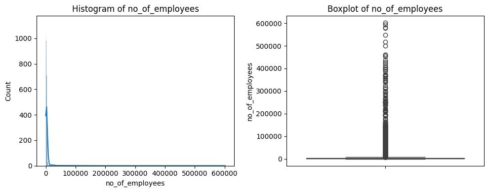

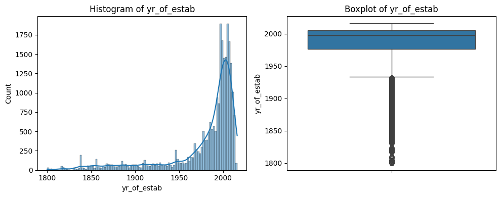

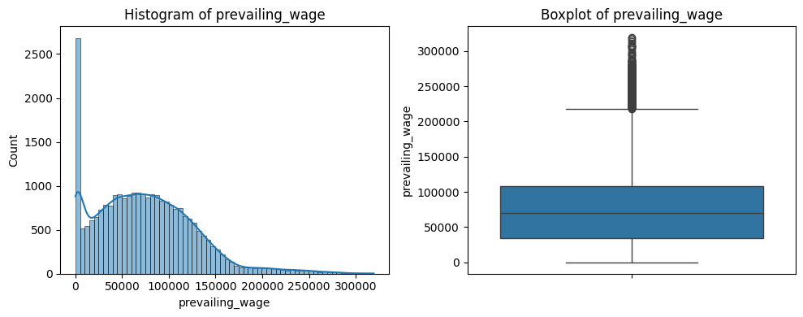

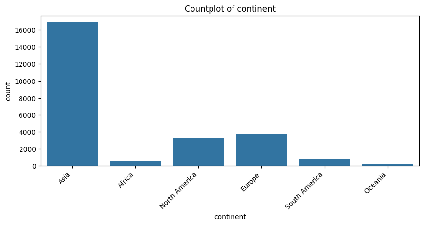

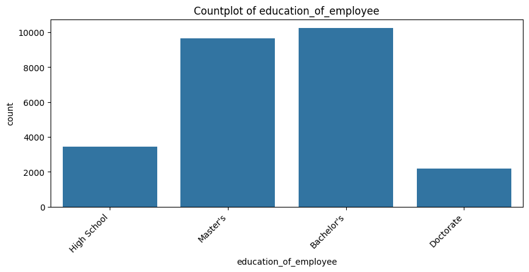

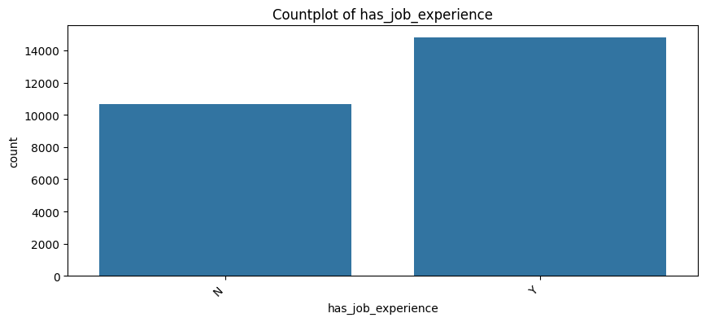

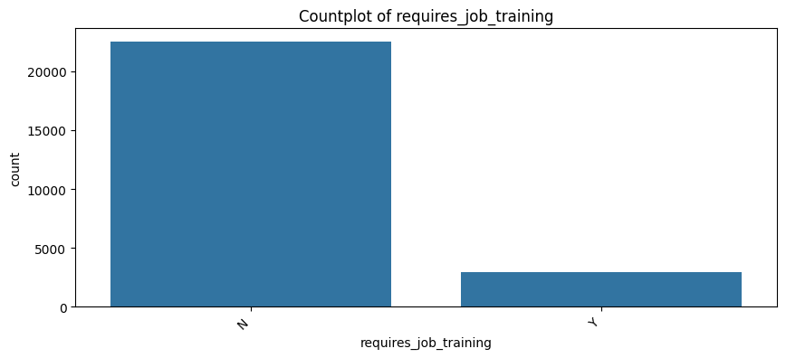

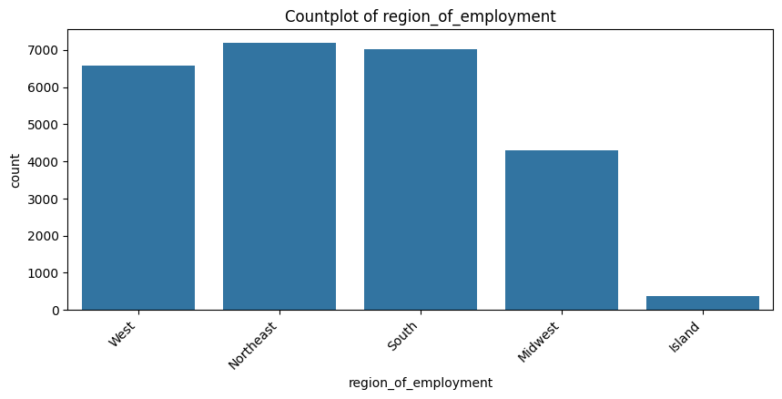

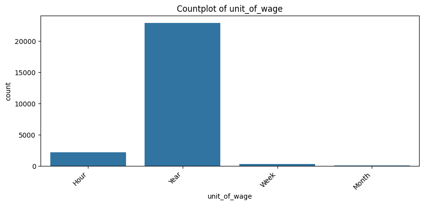

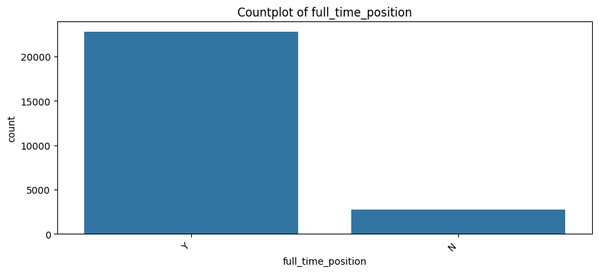

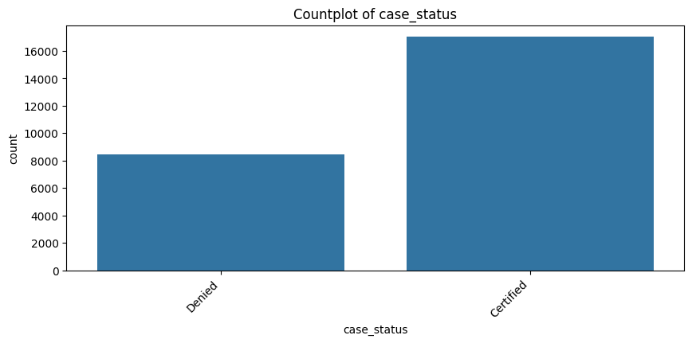

```python
# Define numerical and categorical variables
numerical_columns = ['no_of_employees', 'yr_of_estab', 'prevailing_wage']
categorical_columns = ['continent', 'education_of_employee', 'has_job_experience', 'requires_job_training', 'region_of_employment', 'unit_of_wage', 'full_time_position', 'case_status']

# Histograms and boxplots for numerical variables
for col in numerical_columns:
  plt.figure(figsize=(10, 4))

  plt.subplot(1, 2, 1)
  sns.histplot(data=Visa, x=col, kde=True)
  plt.title(f'Histogram of {col}')

  plt.subplot(1, 2, 2)
  sns.boxplot(data=Visa, y=col)
  plt.title(f'Boxplot of {col}')

  plt.tight_layout()
  plt.show()

# Countplots for categorical variables
for col in categorical_columns:
  plt.figure(figsize=(10, 4))
  sns.countplot(data=Visa, x=col)
  plt.title(f'Countplot of {col}')
  plt.xticks(rotation=45, ha='right')
  plt.show()
```

### Bivariate Analysis

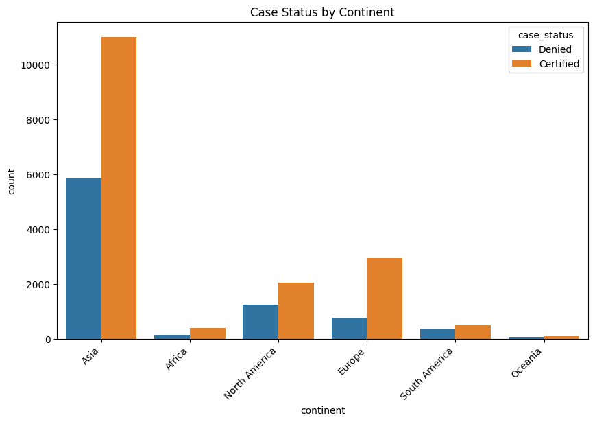

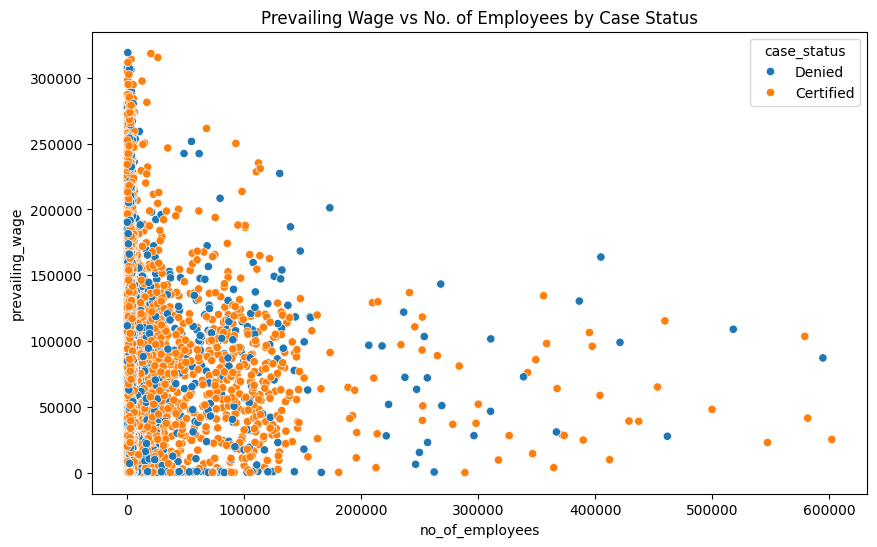

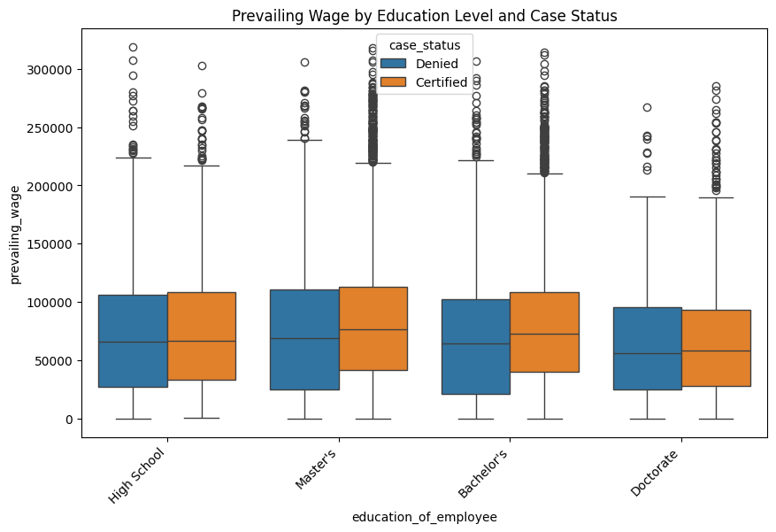

```python
# Categorical vs Categorical
# Example: Analyzing the relationship between 'continent' and 'case_status'
plt.figure(figsize=(10, 6))
sns.countplot(data=Visa, x='continent', hue='case_status')
plt.title('Case Status by Continent')
plt.xticks(rotation=45, ha='right')
plt.show()

# Numerical vs Numerical
# Example: Analyzing the relationship between 'no_of_employees' and 'prevailing_wage'
plt.figure(figsize=(10, 6))
sns.scatterplot(data=Visa, x='no_of_employees', y='prevailing_wage', hue='case_status')
plt.title('Prevailing Wage vs No. of Employees by Case Status')
plt.show()

# Numerical vs Categorical
# Example: Analyzing the relationship between 'prevailing_wage' and 'education_of_employee'
plt.figure(figsize=(10, 6))
sns.boxplot(data=Visa, x='education_of_employee', y='prevailing_wage', hue='case_status')
plt.title('Prevailing Wage by Education Level and Case Status')
plt.xticks(rotation=45, ha='right')
plt.show()
```

Observations

1. **Prevailing Wage and Case Status:** While the scatter plot shows a wide range of prevailing wages, it appears that both Certified and Denied cases occur across the wage spectrum. There isn't a clear linear separation based solely on prevailing wage. However, there might be clusters or thresholds within the wage distribution that are more indicative of one outcome over the other, but this is not immediately obvious from the scatter plot alone due to the density of points.
2. **Number of Employees and Case Status:** Similarly, the number of employees in the company doesn't show a clear separation between Certified and Denied cases. Companies of varying sizes appear to have both certified and denied visa applications. The plot is dominated by companies with a lower number of employees, which is consistent with the univariate analysis showing a right-skewed distribution for this variable.
3. **Combined Effect (Prevailing Wage, No. of Employees, and Case Status):** The plot doesn't reveal a strong synergistic effect between prevailing wage and the number of employees that distinctly separates certified and denied cases. Both certified and denied points are scattered across the plane defined by these two variables.
4. **Outliers:** As observed in the univariate analysis, there are significant outliers in both `no_of_employees` and `prevailing_wage`. These outliers are visible in the scatter plot and occur for both Certified and Denied cases. The presence of these outliers might influence the performance of certain models and might require handling during preprocessing.
5. **Density of Points:** The scatter plot is quite dense, especially at lower values of `no_of_employees` and `prevailing_wage`, making it challenging to visually discern subtle patterns or boundaries between the two classes.

In summary, the scatter plot suggests that `prevailing_wage` and `no_of_employees`, while potentially informative, do not individually or in combination provide a simple linear separation of visa cases into Certified and Denied. Other factors and potentially more complex relationships might be stronger predictors of the case status. Further analysis, possibly involving transformations of these variables or looking at interactions with other features, might reveal more predictive power. The class imbalance observed in the univariate analysis is also implicitly present in this plot, with a visually higher density of Certified points.

[figure not shown]

[figure not shown]

[figure not shown]

[figure not shown]

[figure not shown]

[figure not shown]

[figure not shown]

[figure not shown]

[figure not shown]

[figure not shown]

[figure not shown]

[figure not shown]

[12 more figures not shown]

```python
# Define numerical and categorical variables
numerical_columns = ['no_of_employees', 'yr_of_estab', 'prevailing_wage']
categorical_columns = ['continent', 'education_of_employee', 'has_job_experience', 'requires_job_training', 'region_of_employment', 'unit_of_wage', 'full_time_position', 'case_status']

# Numerical vs. Categorical
for num_col in numerical_columns:
  for cat_col in categorical_columns:
    plt.figure(figsize=(10, 6))
    sns.boxplot(data=Visa, x=cat_col, y=num_col)
    plt.title(f'{num_col} vs {cat_col}')
    plt.xticks(rotation=45, ha='right')
    plt.show()
```

[figure not shown]

```python
# Numerical vs. Numerical (using scatter plots)
sns.pairplot(Visa[numerical_columns])
plt.show()
```

### Multivariate Analysis

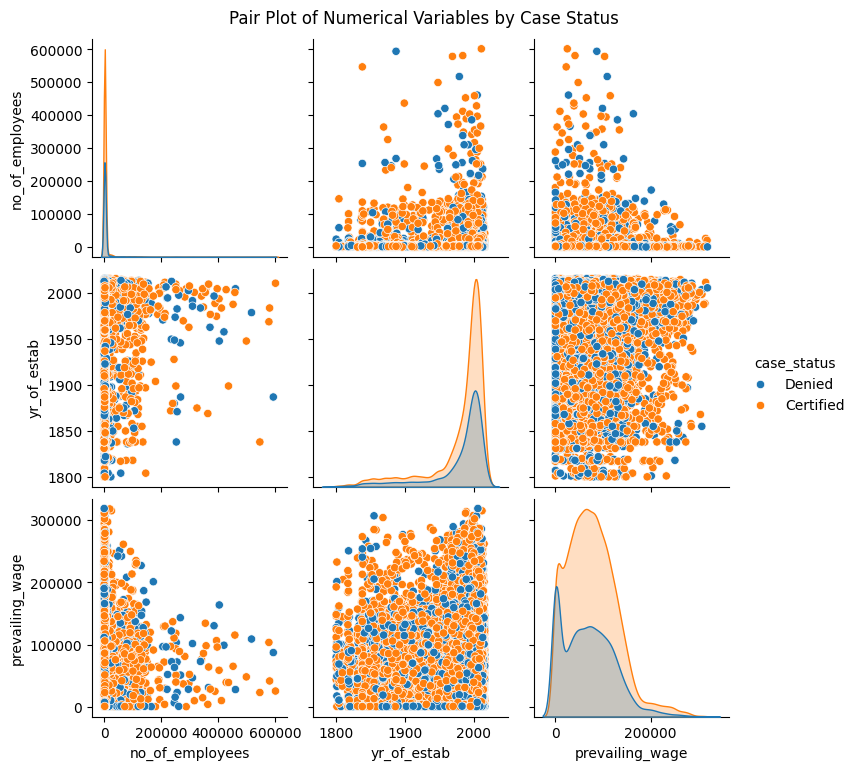

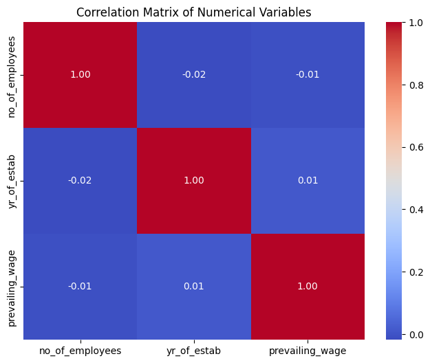

```python
# Pair plot for numerical variables colored by 'case_status'
sns.pairplot(Visa, vars=numerical_columns, hue='case_status')
plt.suptitle('Pair Plot of Numerical Variables by Case Status', y=1.02)
plt.show()

# Correlation matrix for numerical variables
plt.figure(figsize=(8, 6))
correlation_matrix = Visa[numerical_columns].corr()
sns.heatmap(correlation_matrix, annot=True, cmap='coolwarm', fmt=".2f")
plt.title('Correlation Matrix of Numerical Variables')
plt.show()
```

Observations **Numerical vs. Numerical (Pairplot by Case Status):**

- The pair plot colored by `case_status` helps visualize if the combinations of numerical features can separate Certified and Denied cases.
- Looking at the scatter plots, there is no clear linear boundary between the two classes based on any pair of the numerical features (`no_of_employees`, `yr_of_estab`, `prevailing_wage`). Certified and Denied cases are largely interspersed within the observed ranges of these variables.
- The plots reinforce the observations from the bivariate numerical vs. numerical scatter plots: the distributions are heavily skewed, and outliers are present for both classes.
- While a linear separation isn't evident, there might be subtle patterns or non-linear relationships that are not immediately obvious from the scatter plots. For instance, certain clusters of points in the feature space might have a higher proportion of one class over the other, even if the classes overlap significantly.
- The density of points at lower values of `no_of_employees` and `prevailing_wage` is apparent for both Certified and Denied cases.

**Correlation Matrix :**

**Overall:** The correlation matrix shows that the three numerical variables (`no_of_employees`, `yr_of_estab`, and `prevailing_wage`) have extremely weak linear correlations with each other. This suggests that these numerical features are largely independent in terms of their linear relationships.